# Bioinformatics class 14 differential gene expression

## Data Visualization

Get the gene ID for the “CRISPLD2” gene

```r
index <- grep("CRISPLD2", resSig01$symbol)
resSig01 [index, ]
```

```
##                 baseMean log2FoldChange     lfcSE     stat       pvalue
## ENSG00000103196 3096.159       2.626034 0.2674705 9.818031 9.416441e-23
##                         padj   symbol
## ENSG00000103196 3.395524e-20 CRISPLD2
```

```r
rownames(resSig01[index, ])
```

```
## [1] "ENSG00000103196"
```

Now lets plot the counts

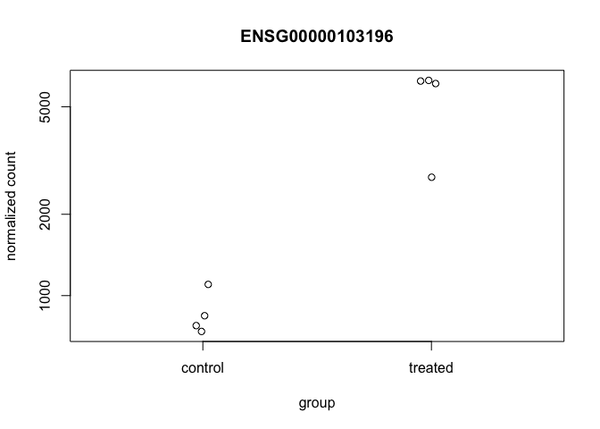

```r
plotCounts(dds, gene="ENSG00000103196", intgroup="dex")
```

```r
#Return the data instead of the counts
d <- plotCounts(dds, gene = "ENSG00000103196", intgroup = "dex", returnData = TRUE)
head(d)
```

```
##                count     dex
## SRR1039508  774.5002 control
## SRR1039509 6258.7915 treated
## SRR1039512 1100.2741 control
## SRR1039513 6093.0324 treated
## SRR1039516  736.9483 control
## SRR1039517 2742.1908 treated
```

Now from this object returned, we can plot a boxplot

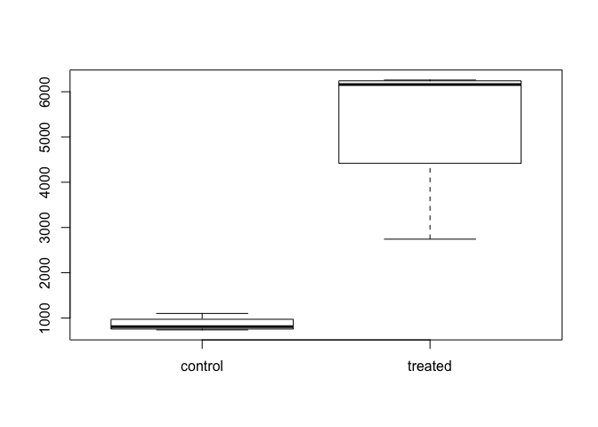

```r
boxplot(count ~ dex, data = d)
```

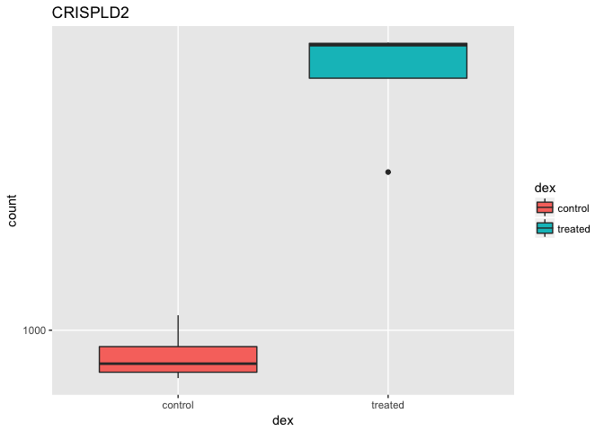

```r
library(ggplot2)
ggplot(d, aes(dex, count)) + geom_boxplot(aes(fill=dex)) + scale_y_log10() + ggtitle("CRISPLD2")
```

## MA and Volcano plots

Add a column called sig to our rull “res” that calls true if padj <0.05 and FALSE if not

```r
res$sig <- res$padj<0.05
table(res$sig)
```

```
##
## FALSE  TRUE
## 12963  2182
```

```r
sum(is.na(res$sig))
```

```
## [1] 23549
```

MA plot shows average expression on the x-axis and log fold change on the y-axis Volcano plot shows the log fold change on the X-axis and the -log10 of the p-value on the Y-axis (the more significant the p-value, the larger the -log10 value will be)

In built MA- plot

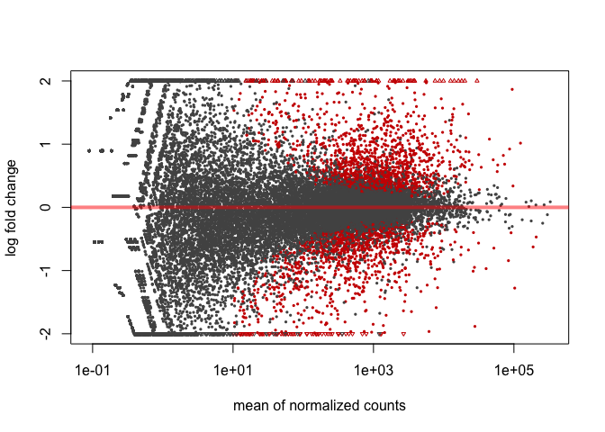

```r
plotMA(res, ylim = c(-2,2))
```

Remove the noise associated with the log2 fold changes from low gene counts

```r
resLFC <- lfcShrink(dds, coef = 2)
resLFC
```

```
## log2 fold change (MAP): dex treated vs control
## Wald test p-value: dex treated vs control
## DataFrame with 38694 rows and 6 columns
##                  baseMean log2FoldChange      lfcSE       stat     pvalue
##                 <numeric>      <numeric>  <numeric>  <numeric>  <numeric>
## ENSG00000000003 747.19420    -0.31838595 0.15271739 -2.0846111 0.03710462
## ENSG00000000005   0.00000             NA         NA         NA         NA
## ENSG00000000419 520.13416     0.19883048 0.09744556  2.0403876 0.04131173
## ENSG00000000457 322.66484     0.02280238 0.13491699  0.1690242 0.86577762
## ENSG00000000460  87.68263    -0.11887370 0.20772938 -0.5726216 0.56690095
## ...                   ...            ...        ...        ...        ...
## ENSG00000283115  0.000000             NA         NA         NA         NA
## ENSG00000283116  0.000000             NA         NA         NA         NA
## ENSG00000283119  0.000000             NA         NA         NA         NA
## ENSG00000283120  0.974916    -0.05944174  0.1514839 -0.3944544  0.6932456
## ENSG00000283123  0.000000             NA         NA         NA         NA
##                      padj
##                 <numeric>
## ENSG00000000003 0.1630257
## ENSG00000000005        NA
## ENSG00000000419 0.1757326
## ENSG00000000457 0.9616577
## ENSG00000000460 0.8157061
## ...                   ...
## ENSG00000283115        NA
## ENSG00000283116        NA
## ENSG00000283119        NA
## ENSG00000283120        NA
## ENSG00000283123        NA
```

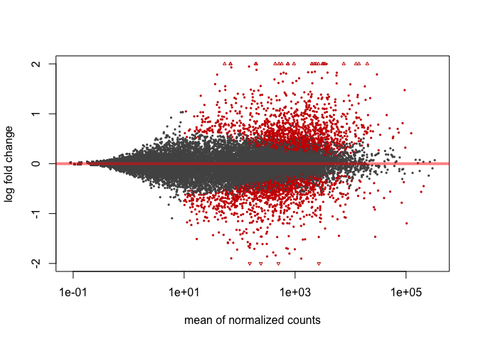

```r
plotMA(resLFC, ylim = c(-2,2))
```

Make a volcano plot

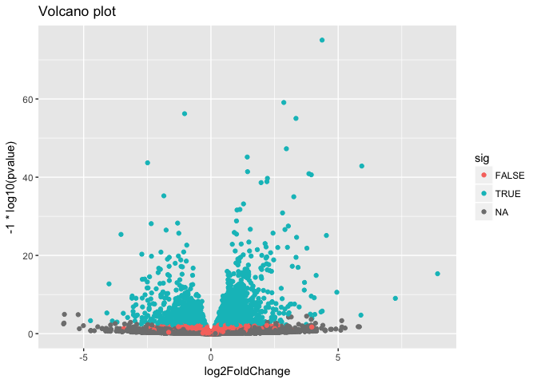

```r
ggplot(as.data.frame(res), aes(log2FoldChange, -1*log10(pvalue), col= sig )) + geom_point() + ggtitle("Volcano plot")
```

Log Transformation of results is needed for heatmaps, PCA, or clustering

```r
#variance stabilizing transformation (VST)
vsdata <- vst(dds, blind=FALSE)
```

## PCA

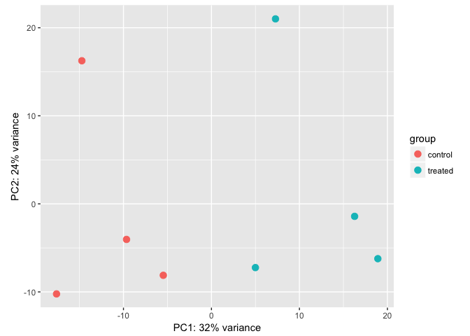

```r
plotPCA(vsdata, intgroup = "dex")
```